# Part 1: Generating composite wealth indices

Craig Jolley

November 22, 2017

## About this document

The purpose of this series of documents is to briefly llustrate some of the concrete techniques and practical choices that must be made in the process of machine learning. They have been created using a system called “R Markdown”, which intersperses code (written in the R programming language) with commentary. Code can be imagined as two-sided communication – it is a structured language which must be interpretable both to a computer and to humans who need to maintain, audit, or improve it. The commentary, of course, only needs to be read by humans and will be ignored by the computer. Finally, this is an *executable document* – all of the code and commentary is written in advance and then the code is executed. That means that there is nothing behind the curtain. Everything that happens is openly disclosed; whether that disclosure makes it easier to understand depends on the programmer’s clarity and the reader’s fluency. Code will be contained in boxes with a gray background, while text output from code execution will be contained in boxes with a white background.

Don’t worry if you can’t interpret the code; the commentary should be enough to explain what is going on. In particular, we’re trying to highlight the places where decisions are made that might be hidden from the view of a machine learning “customer.” On the other hand, don’t skip it entirely – you might see something interesting. Does it seem structured? Are English (or Spanish) words used in ways that seem to make sense? Is it obvious where design choices are made?

We’ll start by loading a series of *packages* – these are widely-shared pieces of code that extend the capabilities of the R language, and are typically loaded at the begining of a section of code. Some programmers refer to these semi-jokingly as “incantations”, because they sometimes make things work even if you don’t fully understand what they’re doing. Remember, though, this really isn’t magic.

```r
library(haven)
library(dplyr)
library(mice)
library(ggplot2)
library(GGally)
```

## Loading data and identifying wealth-related variables

We’re going to be working with the AmericasBarometer “Grand Merge” dataset. This is a compilation of household surveys that were conducted in countries across Latin America, collecting information about political opinions, demographics, and wealth. For now, we’re going to focus on the wealth-related variables.

```r
setwd("C:/Users/Craig/Desktop/Live projects/AI/LAPOP")
lapop <- read_dta('AmericasBarometer Grand Merge 2004-2014 v3.0_FREE.dta') %>%
  filter(year >= 2012)

wealth_data <- lapop %>%
  select(r3,r4,r4a,r5,r6,r7,r8,r12,r14,r15,r18,r1,r16,r26,q10new,q10g)

sapply(wealth_data,function(x) attr(x,'label'))
```

```
                               r3                                r4
           "Refrigerator in Home"                "Landline in Home"
                              r4a                                r5
     "Cellular Telephone in Home" "Number of Vehicles at the House"
                               r6                                r7
        "Washing Machine in Home"          "Microwave Oven in Home"
                               r8                               r12
                "Owns Motorcycle"          "Drinking water in Home"
                              r14                               r15
        "Indoor Bathroom in Home"                "Computer in Home"
                              r18                                r1
       "Internet Service in Home"              "Television in Home"
                              r16                               r26
          "Flat Panel TV in Home" "Home Connected to Sewage System"
                           q10new                              q10g
       "Monthly Household Income"         "Personal Monthly Income"
```

Measuring wealth is tricky – the most relevant measure for development is household consumption, but this is hard to assess in a one-time household survey. LAPOP’s approach is to ask questions about assets (refrigerators, cell phones, microwave ovens, etc.) and also about income.

Assets can be somewhat problematic because some items (especially cell phones) have become dramatically more popular during the survey period – relatively wealthy people had cell phones initially, while a much broader popluation uses them today.

Income can also be diffuclt, because of differences in currencies and purchasing power between countries. Each household was asked to rate theirincome on a scale from 0 to 16, with the meaning of each element on the scale defined differently for each country. For now, we’ll just assume that this scale roughly represents equal purchasing power across the different economies in Latin America

**TODO:** I should actually check how reasonable this assumption is.

To check whether this assumption makes sense, we can see how average wealth varies across the different countries included in the survey:

```r
avg_wealth <- lapop %>%
  group_by(pais) %>%
  summarize(income=mean(q10new,na.rm=TRUE)) %>%
  left_join(data.frame(pais=attr(lapop$pais,'labels'),
                       country=attr(lapop$pais,'labels') %>% names),by='pais')
avg_wealth %>% print(n=nrow(.))
```

```
# A tibble: 22 x 3
        pais    income             country
   <dbl+lbl>     <dbl>              <fctr>
 1         1  7.870416              Mexico
 2         2  5.853487           Guatemala
 3         3  7.662058         El Salvador
 4         4  6.457413            Honduras
 5         5  8.000990           Nicaragua
 6         6  7.199819          Costa Rica
 7         7  6.748948              Panama
 8         8  8.551126            Colombia
 9         9  8.409510             Ecuador
10        11  8.351449                Peru
11        12  8.226709            Paraguay
12        14  9.907205             Uruguay
13        15 10.235787              Brazil
14        21  8.753540  Dominican Republic
15        22  5.288672          "Hait\xed"
16        23  7.110225             Jamaica
17        24  8.579246              Guyana
18        25  9.129480 Trinidad and Tobago
19        26  7.885900              Belize
20        27  9.211217            Suriname
21        28  6.340289             Bahamas
22        29  7.436008            Barbados
```

This makes sense intuitively; relatively prosperous countries like Brazil and Uruguay score close to 10, while Guatemala and Haiti are closer to 5. Note that “Hait\xed” is a casualty of R’s text-parsing capabilities; it should be “Haiti” with an ascending accent above the final “i”.

**TODO**: Can I fix this? Non-standard characters in R are such a headache. (Or I could just leave this comment in as a reflection of my Anglophone bias/privilege/laziness.)

## Missing values

It’s also important to think about missing values. Some survey questions (for example about TVs or cell phones) were answered by more than 99% of households. About 23% didn’t provide any information on income, however, and 25% didn’t say whether they have in-home internet service.

```r
(is.na(wealth_data) %>% colSums) / nrow(wealth_data)
```

```
          r3           r4          r4a           r5           r6
0.0010097950 0.0010097950 0.0009809437 0.0020628670 0.0009953694
          r7           r8          r12          r14          r15
0.0010963489 0.0009520924 0.0009953694 0.0010097950 0.0014858412
         r18           r1          r16          r26       q10new
0.2489577473 0.0010242207 0.0461909090 0.0383145079 0.2288628266
        q10g
0.4889571703
```

We have a few options for dealing with missing data. One would be to simply ignore those records, dropping them completely from the dataset. This is problematic for two reasons. One is that we end up throwing away a lot of data.

```r
(wealth_data %>% na.omit %>% nrow) / nrow(wealth_data)
```

```
[1] 0.3219515
```

In this case, we are left with only 32% of our original data if we disregard any households who failed to answer a question. It’s also possible that throwing away records with missing data may bias our results.

```r
wealth_data %>%
  mutate(r18ans=ifelse(is.na(r18),'NA',r18)) %>%
  group_by(r18ans) %>%
  summarize(income=mean(q10new,na.rm=TRUE))
```

```
# A tibble: 3 x 2
  r18ans    income
   <chr>     <dbl>
1      0  6.819287
2      1 10.301826
3     NA  6.584589
```

What this table is telling us is that those who said they have in-home internet service have an average income score of 10.3, while those without it have an income score of 6.8. Those who did not answer the question had an average income of 6.6. As a result, eliminating those who failed to answer this question from the dataset would skew our results toward higher-income households.

What if we just assume that if someone refuses to answer a question about owning an asset then the answer must be no? This seems reasonable for in-home internet service (`r18`); let’s compare this to landline telephones (`r4`).

```r
wealth_data %>%
  mutate(r4ans=ifelse(is.na(r4),'NA',r4)) %>%
  group_by(r4ans) %>%
  summarize(income=mean(q10new,na.rm=TRUE))
```

```
# A tibble: 3 x 2
  r4ans   income
  <chr>    <dbl>
1     0 6.924080
2     1 9.508145
3    NA 7.392857
```

In the case of landline telephones, those who failed to answer the question are intermediate in income between declared owners and non-owners. If we assume that higher-income households are more likely to have a landline phone, then it is likely that some non-answerers have one and others don’t.

Another possibility would be to replace missing values with an average value for the entire dataset. This would run into similar problems, where (for the example of internet service) we assume that a lot of very poor households have internet when it’s likely that they don’t.

## Imputing missing values

It’s also possible to use a machine learning method to predict the values of missing variables based on the questions that were answered. So, for example, households who didn’t say whether they have a landline phone will be more likely to have one if they have a high income and lots of other assets.

Here we’ll use a method called MICE (Multiple Imputation by Chained Equations) that attempts to predict missing values as well as possible while avoiding changes to the mean and variance of the variable. This assumes that there is no random pattern in who did or didn’t answer questions. We know that this isn’t true – with the in-home internet example we saw that people who didn’t answer the question are significantly poorer, on average, than those who did. So while approaches like MICE are better than simple averages, they too can be unfairly skewed by significant patterns in missing variables. Note that we’re initializing MICE with a *random seed* of `12345`. While the method is inherently random, specifying a random seed allows us to get the same (pseudo-random) result each time we run it.

```r
w_imp <- mice(wealth_data,printFlag = F,seed=12345)
complete(w_imp,1) %>%
  group_by(r18) %>%
  summarize(income=mean(q10new,na.rm=TRUE))
```

```
# A tibble: 2 x 2
        r18    income
  <dbl+lbl>     <dbl>
1         0  6.721877
2         1 10.094047
```

## Dimensionality reduction

This imputed dataset provides a fairly complex picture of a household’s assets and income. To simplify further analysis, we’ll want to boil this down to a single number that captures their “level of wealth.” We’ll do this using principal components analysis (PCA). PCA is a method that takes a dataset in N dimensions (*N*=16 in this case) and converts it into *N* new variables such that variance is maximized by the lowest-numbered principal components. In other words, the first principal component captures as much of the variation in the inital dataset as possible and is a good candidate for our composite wealth index.

We need to make some choices when we do PCA. First, our imputation using MICE is inherently random and produced five different versions of the imputed dataset. (This is why we call it *multiple* imputation.) We could base our wealth index off of just one of these imputations, but this would be sensitive to that random noise. What we’ll do instead is to develop a wealth index for each and see how well they agree. Secondly, we can choose whether to center our variables (so that the mean is equal to zero) and/or scale them (so that the standard deviation is 1) before beginning the PCA caluclation. PCA works best with a normal distribution, and transforming variables in this way is widely considered a good practice. Ours are decidedly not normal. For example, `r1` (television in home) takes only two values (0=no, 1=yes), and 92% of households answered yes. It may be safer not to rescale such a skewed distribution. For the sake of experimentation, we’ll try it both ways.

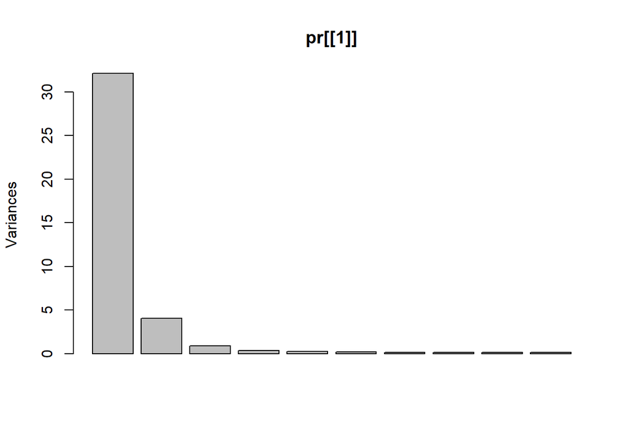

```r
pr <- lapply(1:5,function(x) prcomp(complete(w_imp,x),scale=FALSE,center=TRUE))
plot(pr[[1]])
```

When we do not scale, 82.593% of the overall variance is captured in the first component.

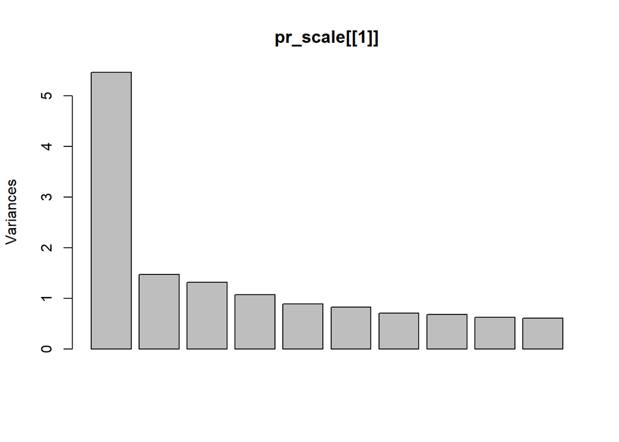

```r
pr_scale <- lapply(1:5,function(x) prcomp(complete(w_imp,x),scale=TRUE,center=TRUE))
plot(pr_scale[[1]])
```

When we do scale, only 34.165% of the overall variance is captured in the first component. At first glance, this might seem like a less effective index, but we need to look closer to learn more about how the two indices differ.

## Imputation and consistency

We’ve run the PCA calculation for each of our five imputations; we want to compare these to each other to see how consistent the construction of the wealth index was. The easiest way to do this is to make pairwise scatter plots of the first principal component for the five different analyses. Because each imputation contains 69321 rows, we’re going to randomly sample just 200 points for easier plotting.

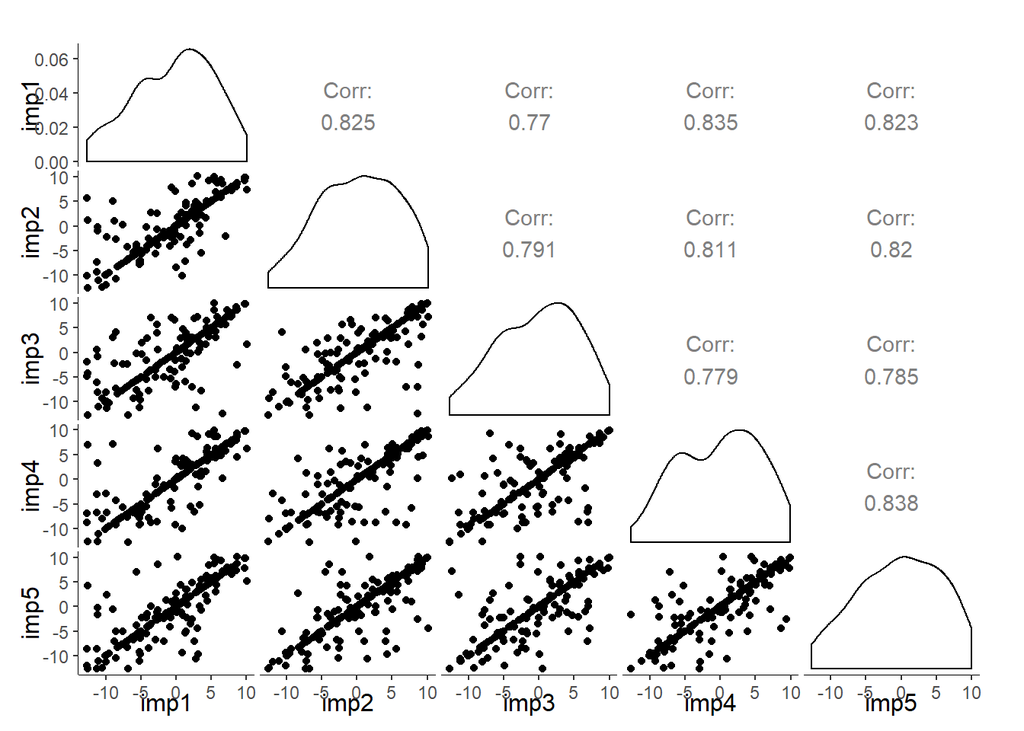

```r
all_pc1 <- data.frame(plyr::llply(1:5, function(i) pr[[i]]$x[,1]))
names(all_pc1) <- c('imp1','imp2','imp3','imp4','imp5')
sample_n(all_pc1,200) %>% ggpairs() + theme_classic()
```

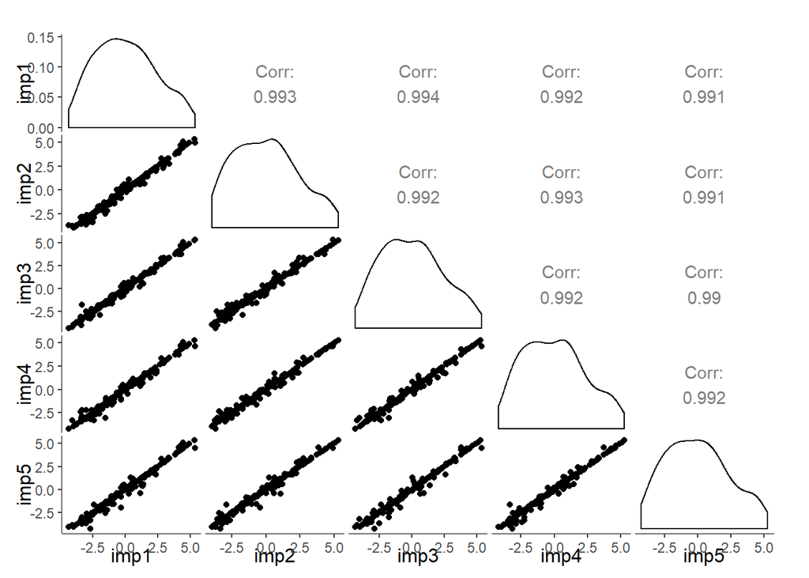

```r
all_pc1_scale <- data.frame(plyr::llply(1:5, function(i) pr_scale[[i]]$x[,1]))
names(all_pc1_scale) <- c('imp1','imp2','imp3','imp4','imp5')
sample_n(all_pc1_scale,200) %>% ggpairs() + theme_classic()
```

In contrast, the version of the index that used scaling in the PCAcalculation shows much more consistency between different imputations. The overall shape is similar, although the double peak that appeared in the unscaled index is gone.

At the very least, the index seems to be pointing in the same direction for all five imputation runs in both cases. (In other words, the correlation values are all close to 1, not -1.) This means that we can create a single – and hopefully more robust – index by averaging across imputations.

```r
all_pc1$avg <- rowMeans(all_pc1)
all_pc1_scale$avg <- rowMeans(all_pc1_scale)
```

## Visualizing the relationship with individual variables

We’ll next want to visualize the effect of each component variable on the index. This will let us see whether high values of the index correspond to high or low wealth, and also which variables impact the index most strongly. Because we’ll be making the same plot twice, abstracting it out into a function allows us to re-use code rather than repeating a lot of typing.

```r
quantile_plot <- function(idx) {
  q25 <- quantile(idx)[2]
  q75 <- quantile(idx)[4]
  qchange <- data.frame(low=colMeans(wealth_data[idx <= q25,],na.rm=TRUE),
                        hi=colMeans(wealth_data[idx >= q75,],na.rm=TRUE))
  qchange[c('q10new','q10g'),'low'] <- qchange[c('q10new','q10g'),'low']/16
  qchange[c('q10new','q10g'),'hi'] <- qchange[c('q10new','q10g'),'hi']/16
  qchange$slope <- qchange$hi - qchange$low
  qchange$label <- rownames(qchange)
  qchange$even <- rank(qchange$hi)/nrow(qchange)*max(c(qchange$low,qchange$hi))

  ggplot(data=qchange) +
    geom_segment(aes(x=0,y=qchange$low,xend=1,yend=qchange$hi,
                     color=qchange$slope),size=1) +
    scale_color_gradient(low='#FF420E',high='#89DA59') +
    geom_text(aes(x=1,y=qchange$even,label=qchange$label,
                  hjust=0,color=qchange$slope),size=5) +
    annotate("text",x=0,y=0,label='Average in lowest quartile',hjust=0) +
    annotate("text",x=1,y=0,label='Average in highest quartile',hjust=1) +
    scale_x_continuous(limits=c(0,1.5)) +
    theme_classic() +
    theme(legend.position='none',
          axis.ticks=element_blank(),
          axis.line=element_blank(),
          axis.text.x=element_blank(),
          axis.title=element_blank(),
          text=element_text(size=20))
}
```

First, we’ll apply our new function to the un-scaled index:

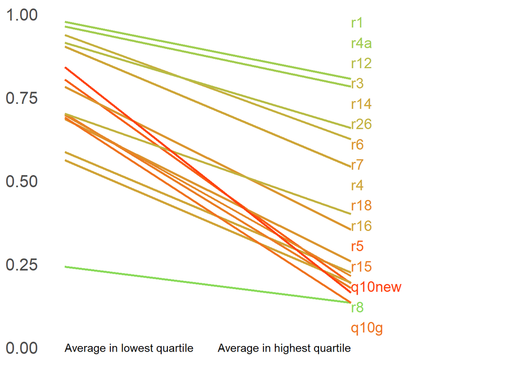

```r
quantile_plot(all_pc1$avg)
```

In this plot, each of the component variables is represented by a downward- sloping line. The color of this line relates to the steepness of the slope; steeper lines are red and more shallow ones are green. The labels on the right-hand side correspond to the order of the endpoints on the right-hand side; this means that the top line represents `r1` (television ownership), followed by `r4a` (mobile phone ownership), and the bottom green line represents `r8` (motorcycle ownership). Finally, all of the asset variables took values of 0 or 1, while the income variables (q10new and q10g) took values from 0 to 16. The averages for these variables were divided by 16 so that they could be displayed on the same vertical scale.

All lines in this plot slope downward. This means that households with a high value of this index have lower incomes and own fewer assets; we’ve actually created an index for poverty, not wealth.

_What we see in this plot is that Some assets – like televisions and mobile phones – are popular among people with widely-varying levels of wealth. Television ownership (`r1`) is nearly 100% among the richest 25% of the population, and more than 75% among the poorest 25%. Conversely, motorcycles (`r8`) are less common among both rich and poor. The steepest, reddest lines are for the income variables `q10new` and `q10g` – this suggests that these variables do the most work in separating rich from poor with this index.

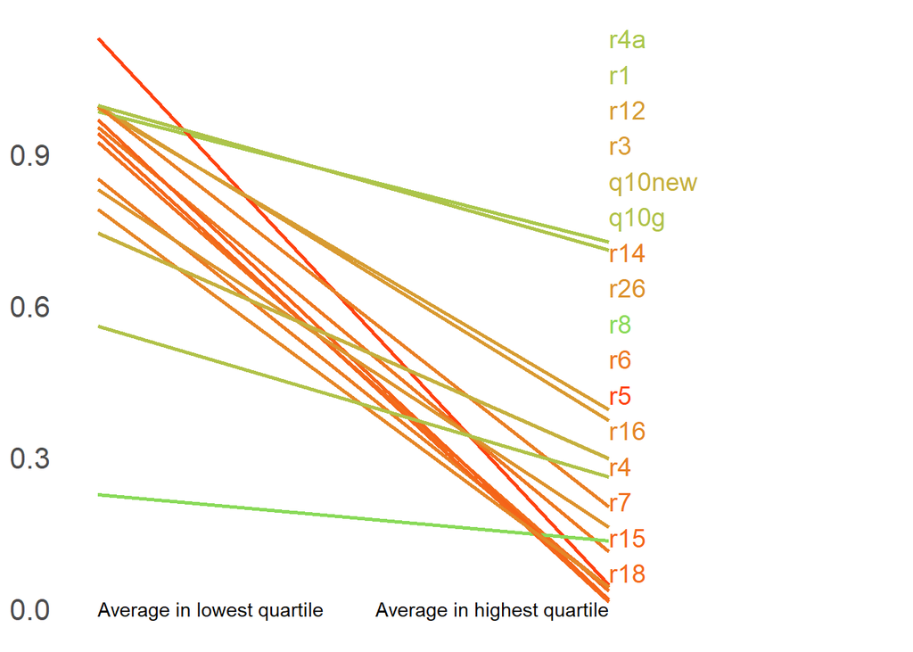

```r
quantile_plot(all_pc1_scale$avg)
```

Comparing this plot to the previous one, we see some common features. All lines slope downward, meaning that households with higher index values are poorer. Television (`r1`) and mobile phone (`r4a`) ownership still have fairly flat lines near the top of the plot, and motorcycle ownership (`r8`) has a fairly flat line near the bottom. The major difference is that many more variables show steep, red lines. In fact, our income variables (`q10new` and `q10g`) are no longer the steepest. Scaling our variables before PCA put them on a more equal footing, so that this index weights asset ownership more heavily.

This could be one reason that the calculation of this index was more consistent between imputations. The unscaled PCA index relied heavily on a single variable that was missing fairly frequently, resulting in a lot more noise from imputation. Our asset-ownership data required much less imputation, and a wealth scale based on these more complete data is probably more reliable.

## Saving results

Finally, we’ll make our wealth indices look a little nicer by inverting them (to make higher values mean more wealth), and re-scaling them to have a mean of zero and a standard deviation of 1.

```r
all_pc1$norm <- -scale(all_pc1$avg)
all_pc1_scale$norm <- -scale(all_pc1_scale$avg)
```

Now that we have developed our wealth indices, we can put the rest of the dataset in a form that will be more suitable for ML testing. First, we’ll want to filter it so that we’re only looking at dates later than 2012 (the same records used to construct the wealth index).

```r
recent <- lapop %>%
  filter(year >= 2012)
```

Next, we’ll need to deal with missing variables. Because different versions of the survey were used in different countries and different years, there will be a lot of missing data. In order to keep the imputation tractable (and reasonably reliable), we’ll restrict our attention to the variables that are present at least 90% of the time. This cutoff is somewhat arbitrary; choosing a more generous cutoff will give us more variables with less reliability.

```r
na_frac <- (is.na(recent) %>% colSums) / nrow(recent)
sum(na_frac < 0.1)
```

```
[1] 106
```

Out of 1791 total variables, only 106 of them are present at least 90% of the time. In addition, some variables are probably irrelevant to our analysis. We’re going to skip variables that probably don’t tell us much about the household in question, such as the language of the survey or the sex of the interviewer. I’m dropping variables that only tell us about the survey sampling (such as sampling strata and primary sampling unit) while keeping those with explicit geographic information. Let’s also drop variables that contain the exact same information as others (such as `nationality` and `q2y`). Note that this is a *choice* – we have to make a call about which data are relevant or irrelevant, and others might make a different choice.

```r
drop_vars <- c('wave','year','idnum','idnum_14','strata','upm','cluster',
               'idiomaq','fecha','wt','weight1500','sexi','colori',
               'uruvbi6notr','uruvbi7notr','nationality','q2y','pid3_t')
good_vars <- na_frac[na_frac < 0.1] %>%
  names %>% setdiff(drop_vars) %>% setdiff(names(wealth_data))
```

We’re now down to just 76 variables that we will attempt to correlate with our wealth indices.

```r
ml_me <- recent[,good_vars] %>%
  mutate(w_unscaled=all_pc1$norm,
         w_scaled=all_pc1_scale$norm)

write.csv(ml_me,'ml_me.csv',row.names=FALSE)
```

Note that this dataset isn’t quite ready to go yet. There are still a lot of missing variables in there. We also still haven’t made decisions about which variables to treat as numeric (because they actually measure something on a scale) and which to treat as factors (using numbers to label qualitatively different things).